**Statistics:**  
is a branch of mathematics dealing with the collection, analysis, interpretation, and presentation of masses of numerical data

Two uses of statistics, to describe or predict, and we call these:

- Descriptive Statistics (to describe)
- Inferential Statistics (to infer)

## Difference between Descriptive and Inferential Statistics

[figure not shown]

Source: http://statisticsbyjim.com/basics/importance-statistics/

# Descriptive Statistics

[figure not shown]

## Types of Variables (Scales of Measurement)

Nominal  
Ordinal  
Interval  
Ratio

[figure not shown]

## Measures of Central Tendency

**Mean**(Sum of all Observations / No. of Observations)  
**median**(mid point which divides data into 2 equal parts)  
**mode**(Most often or repeated the maximum number of times)

[figure not shown]

https://rstudio-pubs-static.s3.amazonaws.com/242140_d3bc74d91e8e47febc2e019762a4d877.html

## Measures of Variability & Shape

variance  
Standard deviation

[figure not shown]

Range  
Quartiles  
IQR

Quartile: It divides the data set into 4 equal parts using Q1 (First Quartile), Q2 (Second Quartile) and Q3 (Third Quartile). Let’s understand it using an example, assume we have a numerical variable having values from 1 to 100. Here, value for Q1 would be 25 (value at 25th percentile), value for Q2 would be 50 (value at 50th percentile i.e. median) and value for Q3 would be 75 (value at 75th percentile). Quartiles are well understood when used with box plots. Box Plots is a five number summary which represents Minimum, Maximum, Q1, Q2 and Q3. Let’s find out.

[figure not shown]

**Skewness**  
Skewness is a measure of symmetry, or more precisely, the lack of symmetry. A distribution, or data set, is symmetric if it looks the same to the left and right of the center point.  
**Kurtosis**  
Kurtosis is a parameter that describes the shape of a random variable’s probability distribution.

[figure not shown]

http://personal.cityu.edu.hk/~meachan/Online%20Anthropometry/Chapter5/Ch5-3.htm

[figure not shown]

```r
time <- c(19.09, 19.55, 17.89, 17.73, 25.15, 27.27, 25.24, 21.05, 21.65, 20.92, 22.61,
    15.71, 22.04, 22.6, 24.25)

library(moments)
# library(e1071)
skewness(time)

# [1] -0.01565162

kurtosis(time)

# [1] 2.301051
```

-0.0156516191272306

2.30105132553941

## Working with Titanic dataset

```r
train <- read.csv("data/train1.csv", stringsAsFactors = FALSE, header = T)
head(train)
```

| PassengerId | Survived | Pclass | Name | Sex | Age | SibSp | Parch | Ticket | Fare | Cabin | Embarked |
| --- | --- | --- | --- | --- | --- | --- | --- | --- | --- | --- | --- |
| 1 | 0 | 3 | Braund, Mr. Owen Harris | male | 22 | 1 | 0 | A/5 21171 | 7.2500 |  | S |
| 2 | 1 | 1 | Cumings, Mrs. John Bradley (Florence Briggs Thayer) | female | 38 | 1 | 0 | PC 17599 | 71.2833 | C85 | C |
| 3 | 1 | 3 | Heikkinen, Miss. Laina | female | 26 | 0 | 0 | STON/O2. 3101282 | 7.9250 |  | S |
| 4 | 1 | 1 | Futrelle, Mrs. Jacques Heath (Lily May Peel) | female | 35 | 1 | 0 | 113803 | 53.1000 | C123 | S |
| 5 | 0 | 3 | Allen, Mr. William Henry | male | 35 | 0 | 0 | 373450 | 8.0500 |  | S |
| 6 | 0 | 3 | Moran, Mr. James | male | NA | 0 | 0 | 330877 | 8.4583 |  | Q |

```r
# find the average(mean) Fare
mean(train$Fare)
# On an average, passengers have paid $32 to board the titanic.
library(DescTools)
Mode(train$Age)
table(train$Age)
# Most common age among passengers on Titanic was 24 years. As you can see, there
# were 30 passengers on board who are 24 years old (highest among all). find out
# the median
median(train$Fare)
# The mid value of Fare variable is $14.45. This means $14.45 divides the data
# into two halves.
```

32.2042079685746

24

```
0.42 0.67 0.75 0.83 0.92    1    2    3    4    5    6    7    8    9   10   11
   1    1    2    2    1    7   10    6   10    4    3    3    4    8    2    4
  12   13   14 14.5   15   16   17   18   19   20 20.5   21   22   23 23.5   24
   1    2    6    1    5   17   13   26   25   15    1   24   27   15    1   30
24.5   25   26   27   28 28.5   29   30 30.5   31   32 32.5   33   34 34.5   35
   1   23   18   18   25    2   20   25    2   17   18    2   15   15    1   18
  36 36.5   37   38   39   40 40.5   41   42   43   44   45 45.5   46   47   48
  22    1    6   11   14   13    2    6   13    5    9   12    2    3    9    9
  49   50   51   52   53   54   55 55.5   56   57   58   59   60   61   62   63
   6   10    7    6    1    8    2    1    4    2    5    2    4    3    4    2
  64   65   66   70 70.5   71   74   80
   2    3    1    2    1    2    1    1
```

14.4542

```r
# variance of fare
var(train$Fare)
# the average of squared difference from mean.  Standard Deviation of Fare
sqrt(var(train$Fare))
sd(train$Fare)
# calculate range
range(train$Fare)
# It shows the lowest value and the highest value in a set of observation.
```

2469.43684574312

49.6934285971809

49.6934285971809

1. 0

2. 512.3292

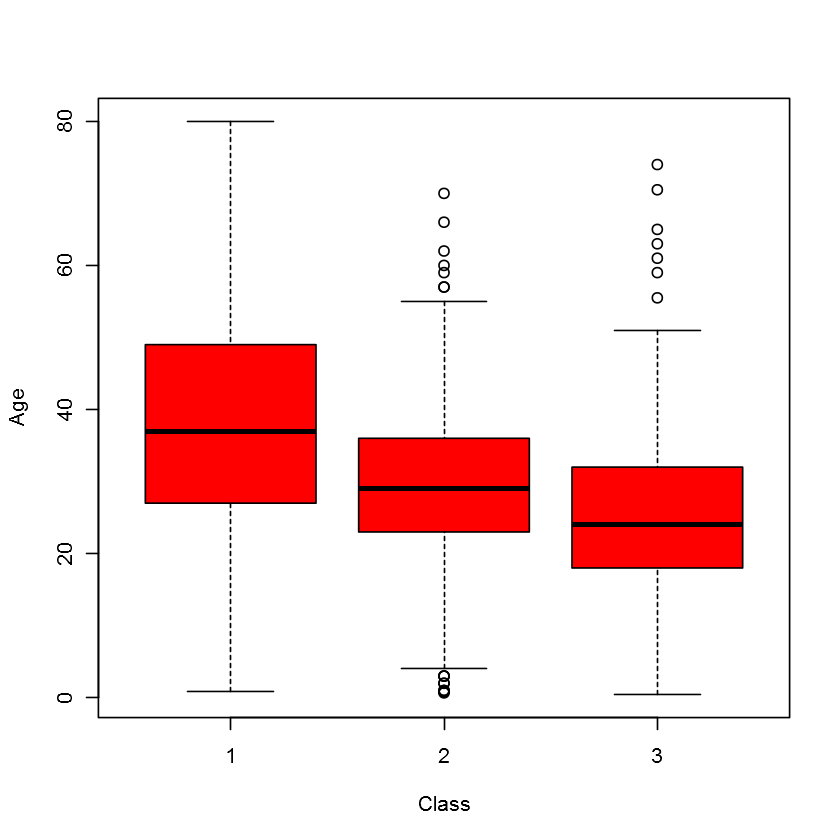

```r
# find boxplot
boxplot(train$Age ~ train$Pclass, xlab = "Class", ylab = "Age", col = c("red"))
```

```r
#base package
fivenum(train$Age)
summary(train)
```

1. 0.42

2. 20

3. 28

4. 38

5. 80

```
  PassengerId       Survived          Pclass          Name
 Min.   :  1.0   Min.   :0.0000   Min.   :1.000   Length:891
 1st Qu.:223.5   1st Qu.:0.0000   1st Qu.:2.000   Class :character
 Median :446.0   Median :0.0000   Median :3.000   Mode  :character
 Mean   :446.0   Mean   :0.3838   Mean   :2.309
 3rd Qu.:668.5   3rd Qu.:1.0000   3rd Qu.:3.000
 Max.   :891.0   Max.   :1.0000   Max.   :3.000

     Sex                 Age            SibSp           Parch
 Length:891         Min.   : 0.42   Min.   :0.000   Min.   :0.0000
 Class :character   1st Qu.:20.12   1st Qu.:0.000   1st Qu.:0.0000
 Mode  :character   Median :28.00   Median :0.000   Median :0.0000
                    Mean   :29.70   Mean   :0.523   Mean   :0.3816
                    3rd Qu.:38.00   3rd Qu.:1.000   3rd Qu.:0.0000
                    Max.   :80.00   Max.   :8.000   Max.   :6.0000
                    NA's   :177
    Ticket               Fare           Cabin             Embarked
 Length:891         Min.   :  0.00   Length:891         Length:891
 Class :character   1st Qu.:  7.91   Class :character   Class :character
 Mode  :character   Median : 14.45   Mode  :character   Mode  :character
                    Mean   : 32.20
                    3rd Qu.: 31.00
                    Max.   :512.33
```

## List of Packages to describe data

Psych  
Hmisc  
pastecs  
summarytools  
skimr  
stargazer

```r
library(psych)
describe(train)
describeBy(train)
```

|  | vars | n | mean | sd | median | trimmed | mad | min | max | range | skew | kurtosis | se |
| --- | --- | --- | --- | --- | --- | --- | --- | --- | --- | --- | --- | --- | --- |
| PassengerId | 1 | 891 | 4.460000e+02 | 2.573538e+02 | 446.0000 | 4.460000e+02 | 330.61980 | 1.00 | 891.0000 | 890.0000 | 0.0000000 | -1.2040412 | 8.621678e+00 |
| Survived | 2 | 891 | 3.838384e-01 | 4.865925e-01 | 0.0000 | 3.548387e-01 | 0.00000 | 0.00 | 1.0000 | 1.0000 | 0.4769135 | -1.7745414 | 1.630146e-02 |
| Pclass | 3 | 891 | 2.308642e+00 | 8.360712e-01 | 3.0000 | 2.385694e+00 | 0.00000 | 1.00 | 3.0000 | 2.0000 | -0.6284264 | -1.2834293 | 2.800944e-02 |
| Name* | 4 | 891 | NaN | NA | NA | NaN | NA | Inf | -Inf | -Inf | NA | NA | NA |
| Sex* | 5 | 891 | NaN | NA | NA | NaN | NA | Inf | -Inf | -Inf | NA | NA | NA |
| Age | 6 | 714 | 2.969912e+01 | 1.452650e+01 | 28.0000 | 2.926923e+01 | 13.34340 | 0.42 | 80.0000 | 79.5800 | 0.3874744 | 0.1597671 | 5.436405e-01 |
| SibSp | 7 | 891 | 5.230079e-01 | 1.102743e+00 | 0.0000 | 2.720898e-01 | 0.00000 | 0.00 | 8.0000 | 8.0000 | 3.6829188 | 17.7269083 | 3.694329e-02 |
| Parch | 8 | 891 | 3.815937e-01 | 8.060572e-01 | 0.0000 | 1.823282e-01 | 0.00000 | 0.00 | 6.0000 | 6.0000 | 2.7398677 | 9.6880847 | 2.700393e-02 |
| Ticket* | 9 | 891 | 2.603185e+05 | 4.716093e+05 | 236171.0000 | 1.956829e+05 | 185104.09260 | 693.00 | 3101298.0000 | 3100605.0000 | 5.2418837 | 28.9026995 | 1.579950e+04 |
| Fare | 10 | 891 | 3.220421e+01 | 4.969343e+01 | 14.4542 | 2.137872e+01 | 10.23617 | 0.00 | 512.3292 | 512.3292 | 4.7712097 | 33.1230682 | 1.664792e+00 |
| Cabin* | 11 | 891 | NaN | NA | NA | NaN | NA | Inf | -Inf | -Inf | NA | NA | NA |
| Embarked* | 12 | 891 | NaN | NA | NA | NaN | NA | Inf | -Inf | -Inf | NA | NA | NA |

|  | vars | n | mean | sd | median | trimmed | mad | min | max | range | skew | kurtosis | se |
| --- | --- | --- | --- | --- | --- | --- | --- | --- | --- | --- | --- | --- | --- |
| PassengerId | 1 | 891 | 4.460000e+02 | 2.573538e+02 | 446.0000 | 4.460000e+02 | 330.61980 | 1.00 | 891.0000 | 890.0000 | 0.0000000 | -1.2040412 | 8.621678e+00 |
| Survived | 2 | 891 | 3.838384e-01 | 4.865925e-01 | 0.0000 | 3.548387e-01 | 0.00000 | 0.00 | 1.0000 | 1.0000 | 0.4769135 | -1.7745414 | 1.630146e-02 |
| Pclass | 3 | 891 | 2.308642e+00 | 8.360712e-01 | 3.0000 | 2.385694e+00 | 0.00000 | 1.00 | 3.0000 | 2.0000 | -0.6284264 | -1.2834293 | 2.800944e-02 |
| Name* | 4 | 891 | NaN | NA | NA | NaN | NA | Inf | -Inf | -Inf | NA | NA | NA |
| Sex* | 5 | 891 | NaN | NA | NA | NaN | NA | Inf | -Inf | -Inf | NA | NA | NA |
| Age | 6 | 714 | 2.969912e+01 | 1.452650e+01 | 28.0000 | 2.926923e+01 | 13.34340 | 0.42 | 80.0000 | 79.5800 | 0.3874744 | 0.1597671 | 5.436405e-01 |
| SibSp | 7 | 891 | 5.230079e-01 | 1.102743e+00 | 0.0000 | 2.720898e-01 | 0.00000 | 0.00 | 8.0000 | 8.0000 | 3.6829188 | 17.7269083 | 3.694329e-02 |
| Parch | 8 | 891 | 3.815937e-01 | 8.060572e-01 | 0.0000 | 1.823282e-01 | 0.00000 | 0.00 | 6.0000 | 6.0000 | 2.7398677 | 9.6880847 | 2.700393e-02 |
| Ticket* | 9 | 891 | 2.603185e+05 | 4.716093e+05 | 236171.0000 | 1.956829e+05 | 185104.09260 | 693.00 | 3101298.0000 | 3100605.0000 | 5.2418837 | 28.9026995 | 1.579950e+04 |
| Fare | 10 | 891 | 3.220421e+01 | 4.969343e+01 | 14.4542 | 2.137872e+01 | 10.23617 | 0.00 | 512.3292 | 512.3292 | 4.7712097 | 33.1230682 | 1.664792e+00 |
| Cabin* | 11 | 891 | NaN | NA | NA | NaN | NA | Inf | -Inf | -Inf | NA | NA | NA |
| Embarked* | 12 | 891 | NaN | NA | NA | NaN | NA | Inf | -Inf | -Inf | NA | NA | NA |

```r
library(Hmisc)
Hmisc::describe(train)
```

```
train

 12  Variables      891  Observations
--------------------------------------------------------------------------------
PassengerId
       n  missing distinct     Info     Mean      Gmd      .05      .10
     891        0      891        1      446    297.3     45.5     90.0
     .25      .50      .75      .90      .95
   223.5    446.0    668.5    802.0    846.5

lowest :   1   2   3   4   5, highest: 887 888 889 890 891
--------------------------------------------------------------------------------
Survived
       n  missing distinct     Info      Sum     Mean      Gmd
     891        0        2     0.71      342   0.3838   0.4735

--------------------------------------------------------------------------------
Pclass
       n  missing distinct     Info     Mean      Gmd
     891        0        3     0.81    2.309   0.8631

Value          1     2     3
Frequency    216   184   491
Proportion 0.242 0.207 0.551
--------------------------------------------------------------------------------
Name
       n  missing distinct
     891        0      891

lowest : Abbing, Mr. Anthony                    Abbott, Mr. Rossmore Edward            Abbott, Mrs. Stanton (Rosa Hunt)       Abelson, Mr. Samuel                    Abelson, Mrs. Samuel (Hannah Wizosky)
highest: Yousseff, Mr. Gerious                  Yrois, Miss. Henriette ("Mrs Harbeck") Zabour, Miss. Hileni                   Zabour, Miss. Thamine                  Zimmerman, Mr. Leo
--------------------------------------------------------------------------------
Sex
       n  missing distinct
     891        0        2

Value      female   male
Frequency     314    577
Proportion  0.352  0.648
--------------------------------------------------------------------------------
```

[output cut: 39 more lines]

```
--------------------------------------------------------------------------------
Cabin
       n  missing distinct
     204      687      147

lowest : A10 A14 A16 A19 A20, highest: F33 F38 F4  G6  T
--------------------------------------------------------------------------------
Embarked
       n  missing distinct
     889        2        3

Value          C     Q     S
Frequency    168    77   644
Proportion 0.189 0.087 0.724
--------------------------------------------------------------------------------
```

```r
library(pastecs)
stat.desc(train)
```

|  | PassengerId | Survived | Pclass | Name | Sex | Age | SibSp | Parch | Ticket | Fare | Cabin | Embarked |
| --- | --- | --- | --- | --- | --- | --- | --- | --- | --- | --- | --- | --- |
| nbr.val | 8.910000e+02 | 891.00000000 | 8.910000e+02 | NA | NA | 7.140000e+02 | 891.00000000 | 891.00000000 | NA | 891.000000 | NA | NA |
| nbr.null | 0.000000e+00 | 549.00000000 | 0.000000e+00 | NA | NA | 0.000000e+00 | 608.00000000 | 678.00000000 | NA | 15.000000 | NA | NA |
| nbr.na | 0.000000e+00 | 0.00000000 | 0.000000e+00 | NA | NA | 1.770000e+02 | 0.00000000 | 0.00000000 | NA | 0.000000 | NA | NA |
| min | 1.000000e+00 | 0.00000000 | 1.000000e+00 | NA | NA | 4.200000e-01 | 0.00000000 | 0.00000000 | NA | 0.000000 | NA | NA |
| max | 8.910000e+02 | 1.00000000 | 3.000000e+00 | NA | NA | 8.000000e+01 | 8.00000000 | 6.00000000 | NA | 512.329200 | NA | NA |
| range | 8.900000e+02 | 1.00000000 | 2.000000e+00 | NA | NA | 7.958000e+01 | 8.00000000 | 6.00000000 | NA | 512.329200 | NA | NA |
| sum | 3.973860e+05 | 342.00000000 | 2.057000e+03 | NA | NA | 2.120517e+04 | 466.00000000 | 340.00000000 | NA | 28693.949300 | NA | NA |
| median | 4.460000e+02 | 0.00000000 | 3.000000e+00 | NA | NA | 2.800000e+01 | 0.00000000 | 0.00000000 | NA | 14.454200 | NA | NA |
| mean | 4.460000e+02 | 0.38383838 | 2.308642e+00 | NA | NA | 2.969912e+01 | 0.52300786 | 0.38159371 | NA | 32.204208 | NA | NA |
| SE.mean | 8.621678e+00 | 0.01630146 | 2.800944e-02 | NA | NA | 5.436405e-01 | 0.03694329 | 0.02700393 | NA | 1.664792 | NA | NA |
| CI.mean.0.95 | 1.692119e+01 | 0.03199378 | 5.497225e-02 | NA | NA | 1.067328e+00 | 0.07250613 | 0.05299881 | NA | 3.267377 | NA | NA |
| var | 6.623100e+04 | 0.23677222 | 6.990151e-01 | NA | NA | 2.110191e+02 | 1.21604308 | 0.64972824 | NA | 2469.436846 | NA | NA |
| std.dev | 2.573538e+02 | 0.48659245 | 8.360712e-01 | NA | NA | 1.452650e+01 | 1.10274343 | 0.80605722 | NA | 49.693429 | NA | NA |
| coef.var | 5.770266e-01 | 1.26770139 | 3.621485e-01 | NA | NA | 4.891222e-01 | 2.10846437 | 2.11234407 | NA | 1.543073 | NA | NA |